# NHL Data Analysis

Andrew Daly

2023-11-09

## Prerequisites

You will need GGPlot and XML2. These can be insalled by running:  
**install.packages(“ggplot2”)**  
**install.packages(“xml2”)**

## Details

In this assignment I will demonstrate how to scrape, clean and combine data sets. In addition, I will demonstrate how to generate summary statistics and simple plots. I will be scraping initial NHL data from [Scrape This Site](https://www.scrapethissite.com/pages/forms/).

Clear your environment.

```r
rm(list=ls())
```

### Create initial data frame with scraped data

Load XML library to parse results from the web pages.

```r
library(xml2)
```

Initialize empty vectors to hold data scraped from the web pages.

```r
all_team <- character(0)
all_year <- character(0)
all_wins <- character(0)
all_losses <- character(0)
```

Scrape the hockey data from *Scrape This Site*

```r
for (i in 1:24){  #24 pages of data

  Sys.sleep(5) # Add 5-second wait time

  # Paste number (1, 2, 3, ...) at end of base URL
  url<-paste("https://www.scrapethissite.com/pages/forms/?page_num=", i, sep="")
  page<-read_html(url)

  team <- xml_text(xml_find_all(page, "//tr/td[1]"))
  all_team <- c(all_team, team) # Append to names vector

  year <- xml_text(xml_find_all(page, "//tr/td[2]"))
  all_year <- c(all_year, year) # Append to years vector

  wins <- xml_text(xml_find_all(page, "//tr/td[3]"))
  all_wins <- c(all_wins, wins) # Append to wins vector

  losses <- xml_text(xml_find_all(page, "//tr/td[4]"))
  all_losses <- c(all_losses, losses) # Append to losses vector

  # Wait a random amount of time before moving to the next page
  random_value <- sample(2:20, 1)
  Sys.sleep(random_value)

  }
```

Combine individual vectors into a data frame.

```r
nhl0 <- data.frame(all_team, all_year, all_wins, all_losses)
colnames(nhl0) <- c("team", "year", "wins", "losses")
```

### Clean the data.

- Remove white space.

```r
nhl0$team <- trimws(nhl0$team)
nhl0$year <- trimws(nhl0$year)
nhl0$wins <- trimws(nhl0$wins)
nhl0$losses <- trimws(nhl0$losses)
```

Convert Year, Wins, and Losses columns to Integer data type.

```r
nhl0$year <- as.integer(nhl0$year)
nhl0$wins <- as.integer(nhl0$wins)
nhl0$losses <- as.integer(nhl0$losses)
```

Review the column names and data types in the data frame.

```r
str(nhl0)
```

```
## 'data.frame':    582 obs. of  4 variables:
##  $ team  : chr  "Boston Bruins" "Buffalo Sabres" "Calgary Flames" "Chicago Blackhawks" ...
##  $ year  : int  1990 1990 1990 1990 1990 1990 1990 1990 1990 1990 ...
##  $ wins  : int  44 31 46 49 34 37 31 46 27 39 ...
##  $ losses: int  24 30 26 23 38 37 38 24 39 30 ...
```

Review the first 10 rows of data in the data frame.

```
##                     team year wins losses
## 1          Boston Bruins 1990   44     24
## 2         Buffalo Sabres 1990   31     30
## 3         Calgary Flames 1990   46     26
## 4     Chicago Blackhawks 1990   49     23
## 5      Detroit Red Wings 1990   34     38
## 6        Edmonton Oilers 1990   37     37
## 7       Hartford Whalers 1990   31     38
## 8      Los Angeles Kings 1990   46     24
## 9  Minnesota North Stars 1990   27     39
## 10    Montreal Canadiens 1990   39     30
```

### Import additional data for integration

Read excel file for more corresponding NHL data.

```r
library(readxl)
nhl_expanded <- read_excel("nhl_2012-2021.xlsx")
```

- Clean and transform 2012-2021 NHL data to integrate with scrapped data.

Remove additional columns in NHL expanded data frame by creating another data frame with relevant columns.

```r
nhl_expanded2 <- data.frame(nhl_expanded$team, nhl_expanded$year, nhl_expanded$wins, nhl_expanded$losses)
colnames(nhl_expanded2) <- c("team", "year", "wins", "losses")
```

Merge the two data frames vertically. The data will share the same variables and increase in observation depth

```r
nhl2 <- rbind(nhl0, nhl_expanded2)
```

Create a new variable for win percentage. The table below shows the addition of the win percentage column.

| team | year | wins | losses | Win_percentage |
| --- | --- | --- | --- | --- |
| Boston Bruins | 1990 | 44 | 24 | 0.65 |
| Buffalo Sabres | 1990 | 31 | 30 | 0.51 |
| Calgary Flames | 1990 | 46 | 26 | 0.64 |
| Chicago Blackhawks | 1990 | 49 | 23 | 0.68 |

### Import NHL arena data for integration

Import and read the NHL arenas comma separated values file.

```r
arena <- read.csv("nhl_hockey_arenas.csv")
```

Rename the columns in arena to match the other data frame for integration.

Drop unnecessary columns in the arena data frame.

```r
arena$Opening.Year <- NULL
```

Output the first 5 rows of data in the arena data frame.

```
##              team                 arena              location capacity
## 1   Anaheim Ducks          Honda Center   Anaheim, California    17174
## 2 Arizona Coyotes      Gila River Arena     Glendale, Arizona    17125
## 3   Boston Bruins             TD Garden Boston, Massachusetts    17565
## 4  Buffalo Sabres        KeyBank Center     Buffalo, New York    19070
## 5  Calgary Flames Scotiabank Saddledome      Calgary, Alberta    19289
```

Check for spelling errors within the team name column. Some teams may have adapted new names over the years.

```
##  [1] "Anaheim Ducks"         "Arizona Coyotes"       "Boston Bruins"
##  [4] "Buffalo Sabres"        "Calgary Flames"        "Carolina Hurricanes"
##  [7] "Chicago Blackhawks"    "Colorado Avalanche"    "Columbus Blue Jackets"
## [10] "Dallas Stars"          "Detroit Red Wings"     "Edmonton Oilers"
## [13] "Florida Panthers"      "Los Angeles Kings"     "Minnesota Wild"
## [16] "Montreal Canadiens"    "Nashville Predators"   "New Jersey Devils"
## [19] "New York Islanders"    "New York Rangers"      "Ottawa Senators"
## [22] "Philadelphia Flyers"   "Pittsburgh Penguins"   "San Jose Sharks"
## [25] "St. Louis Blues"       "Tampa Bay Lightning"   "Toronto Maple Leafs"
## [28] "Vancouver Canucks"     "Vegas Golden Knights"  "Washington Capitals"
## [31] "Winnipeg Jets"         "Seattle Kracken"
```

Correct the misspelled data and modernize team names from the same franchise.

```r
arena$team <- ifelse(arena$team == "Seattle Kracken", "Seattle Kraken", arena$team)
nhl2$team <- ifelse(nhl2$team == "Mighty Ducks of Anaheim", "Anaheim Ducks", nhl2$team)
```

Merge the data horizontally, whereby adding more columns to the existing data frame

```r
nhl <- merge(nhl2, arena, by = "team", all.x = TRUE)
head(nhl, 5)
```

```
##            team year wins losses Win_percentage        arena
## 1 Anaheim Ducks 2012   30     12           0.71 Honda Center
## 2 Anaheim Ducks 2002   40     27           0.60 Honda Center
## 3 Anaheim Ducks 2005   43     27           0.61 Honda Center
## 4 Anaheim Ducks 2020   17     30           0.36 Honda Center
## 5 Anaheim Ducks 2009   39     32           0.55 Honda Center
##              location capacity
## 1 Anaheim, California    17174
## 2 Anaheim, California    17174
## 3 Anaheim, California    17174
## 4 Anaheim, California    17174
## 5 Anaheim, California    17174
```

```r
nhl$arena <- ifelse(nhl$team == "New York Islanders",
                     ifelse(nhl$year >= 2012, "Nassau Coliseum",
                            ifelse(nhl$year < 2012, "Barclays Center", nhl$arena)),
                     nhl$arena)

nhl$location <- ifelse(nhl$team == "New York Islanders",
                        ifelse(nhl$arena == "Nassau Coliseum", "Uniondale, New York",
                               ifelse(nhl$arena == "Barclays Center", "Brooklyn, New York", nhl$location)),
                        nhl$location)

nhl$capacity <- ifelse(nhl$team == "New York Islanders",
                        ifelse(nhl$arena == "Nassau Coliseum", 13900,
                               ifelse(nhl$arena == "Barclays Center", 15795, nhl$capacity)),
                        nhl$capacity)
```

The above command creates exact duplicates, multiple rows containing the same data. Remove those rows.

```r
nhl <- nhl[!duplicated(nhl), ]
```

Save the final data frame to a comma separated values file without row names.

```r
write.csv(nhl, "hockey_data.csv", row.names = FALSE)
```

## Data Modeling

### 1990 Teams Winning More Than 50% Of Regular Season Games

Embed ggplot listing all NHL teams that won more than 40 of the 80 regular season games in 1990.

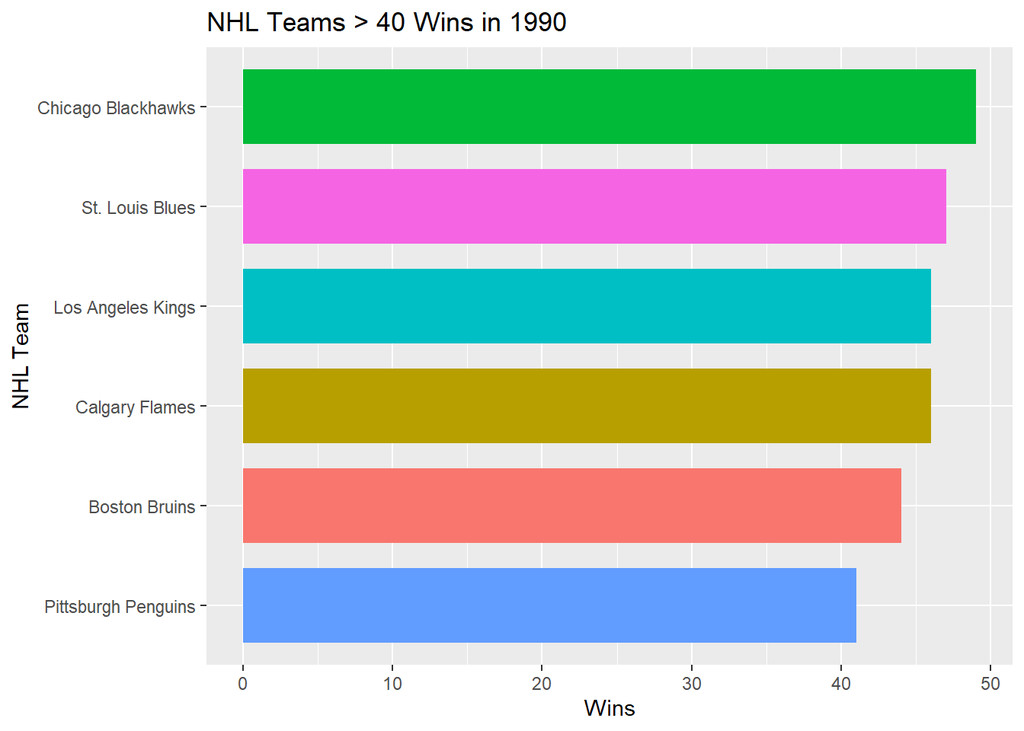

### Philadelphia Flyers Wins Each Season

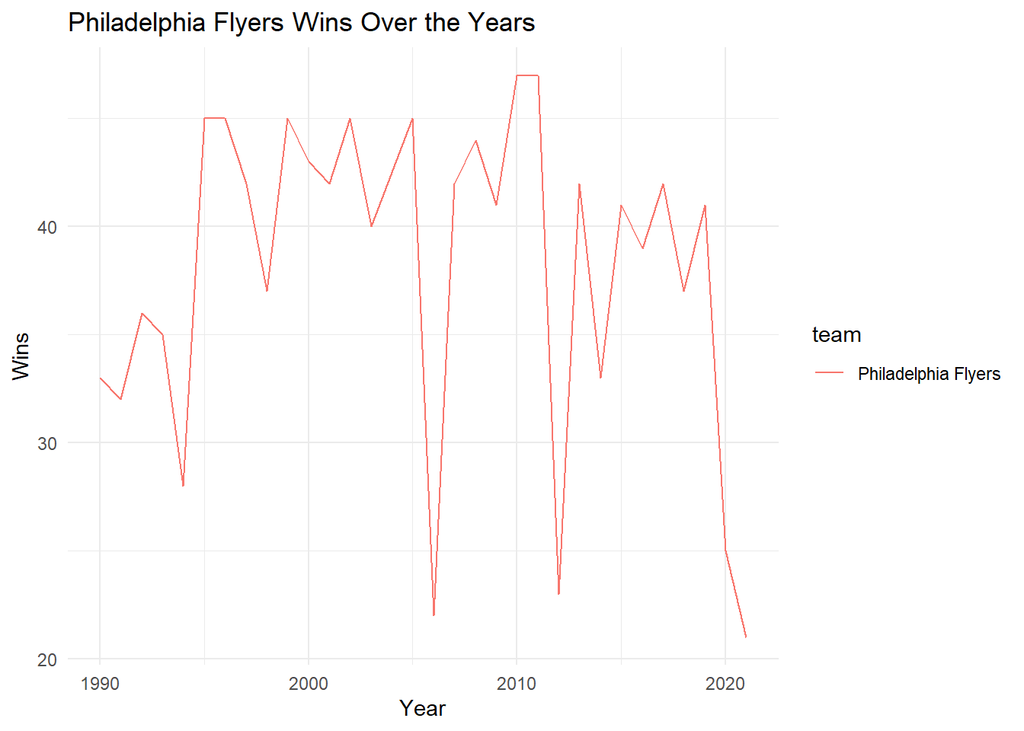

### Distribution of Win Percentages by Team

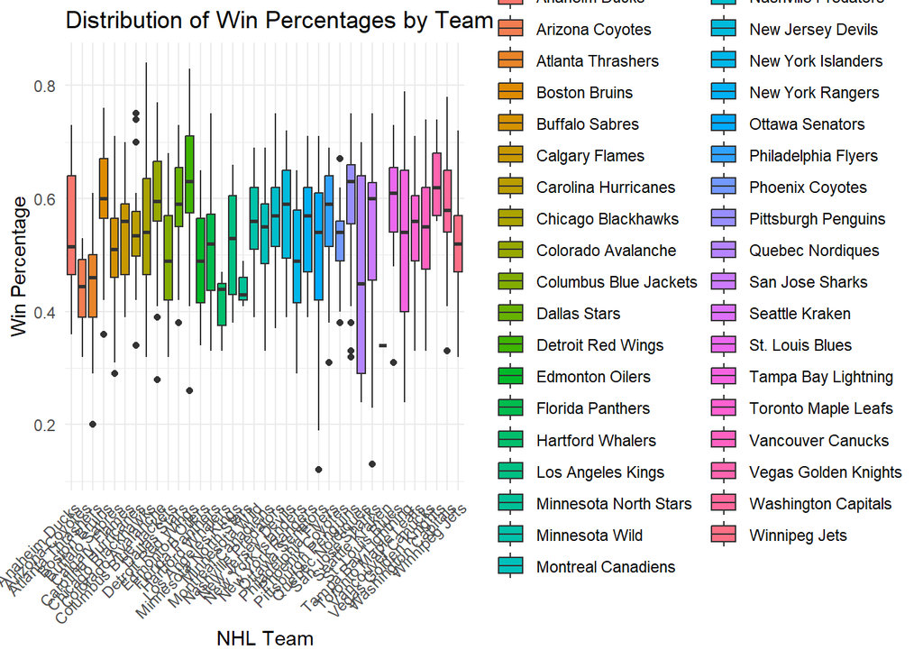

### NHL Win Percentage Over the Years

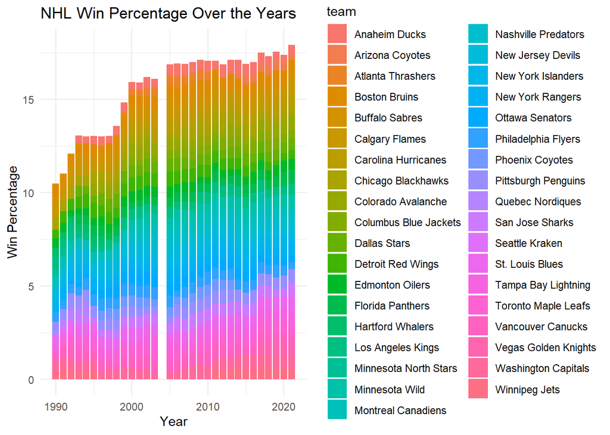

### NHL Arena Capacities

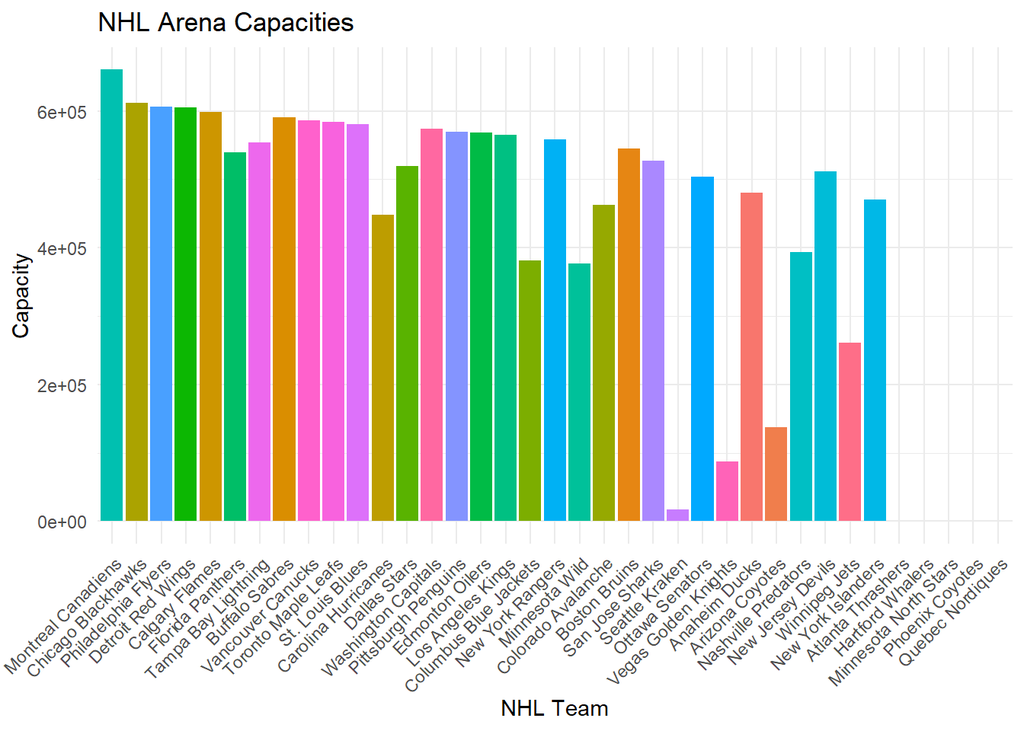